# R Notebook

## BONUS: Testing Many Models

Above, we have shown regression diagnostics for just one model. But, now our colleague has proposed fifty. The model above shows signs of misspecification and heteroskedasticity - which gives us reason to consider testing the other 49 models and comparing them.

To do this, we will use an R function that applies the test to each model and returns a data.frame with one row per model and one column per test. It’s OK if you don’t feel comfortable writing and editing functions just yet - but this is a useful example of how the flexibility to writing functions can allow you to do scale your analysis from one to many models easily.

First the function, we’ll call it `regress_battery` - as in a battery of regression tests.

```r
# Functions are just named objects in R of a special type
# Here we name our function, and we say that it is a function with two "arguments"
# the first model, the second order_var. The default value of order_var is NULL
regress_battery <- function(model, order_var = NULL) {
  # model = a regression model object, of class lm
  # order_var = a vector of values to reorder the regression test by

  # First, extract the residuals from the model, we need these for some
  # types of regression tests
    ordered_resids <- residuals(model)
  if (!is.null(order_var)) { # if order is given, reorder the residuals
      ordered_resids <- ordered_resids[order(order_var)]
      order_by <- order_var[1]
  } else {
    # If no order is given, specify that the order value is NA
      order_by <- NA
  }
  suppressWarnings({ # avoid some annoying output to the console caused by the tests
    out <- data.frame(
            order_by = order_by, # give an example value of the sort by data
            breusch_pagan = bptest(model)$p.value, # p-value from bptest
            goldfeld_quandt = gqtest(model)$p.value,
            harvey_collier = harvtest(model, order.by = order_var)$p.value,
            reset = reset(model, power = 2:4)$p.value,
            rainbow = raintest(model, order.by = order_var)$p.value,
            box_test = Box.test(ordered_resids)$p.value,
            ljung_test = Box.test(ordered_resids, type = "Ljung")$p.value,
            durbin_watson = dwtest(model, order.by = order_var)$p.value,
            breusch_godfrey = bgtest(model, order.by = order_var)$p.value
          )
    })

  out[, 2:10] <- apply(out[, 2:10], 2, round, 3) # round p-values to the 0.001
  row.names(out) <- NULL
  return(out) # return the data.frame
}

# Now call the function
regress_battery(m1, order_var = by_group$data[[15]]$distid)
```

| order_by | breusch_pagan | goldfeld_quandt | harvey_collier | reset | rainbow | box_test | ljung_test | durbin_watson | breusch_godfrey |
| --- | --- | --- | --- | --- | --- | --- | --- | --- | --- |
| 74 | 0 | 0.255 | 0.626 | 0.058 | 0.998 | 0.875 | 0.874 | 0.41 | 0.874 |

This example model shows signs of heteroskedacticity and perhaps a need for polynomial terms, but otherwise checks out. However, it isn’t about how a single model performs - we want to assess collectively how the fifty models on our fifty subsamples perform.

To test all of them, we use the `rowwise()` operator to operate on each row of our `by_group` data frame. We take one model and the data set it was fit to from the `model` and `data` columns respectively, and then produce a new data.frame with 50 rows of regression diagnostiics.

```r
# Group the data and appply the function to each model
mod_test_ss1 <- by_group %>%
  rowwise() %>%
  do(regress_battery(model = .$base_model, order_var = .$data$ss1))
mod_test_ss1$order_by <- "ss1"

mod_test_ss1 <- bind_cols(by_group %>%
                            dplyr::select(grade, subject, test_year),
                          mod_test_ss1)

# Group the data and appply the function to each model
mod_test_distid <- by_group %>%
  rowwise() %>%
  do(regress_battery(model = .$base_model, order_var = .$data$distid))
mod_test_distid$order_by <- "distid"

mod_test_distid <- bind_cols(by_group %>% dplyr::select(grade, subject, test_year),
                          mod_test_distid)
```

If you want, you can inspect the results for these models.

Now we reshape and plot

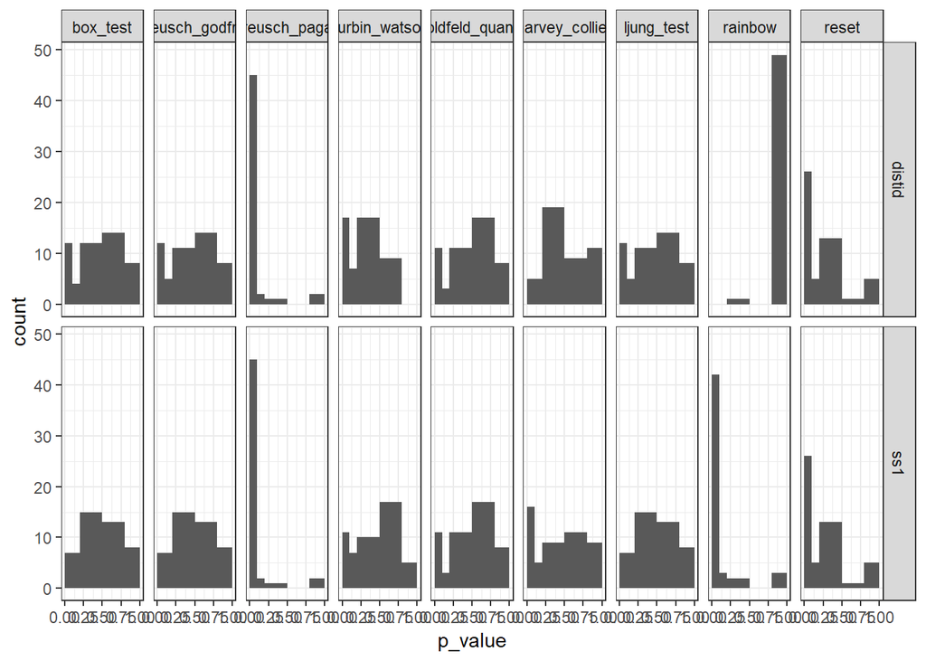

```r
plotdf <- bind_rows(mod_test_ss1, mod_test_distid) %>%
  as.data.frame

names(plotdf)[5:13] <- paste0("p_value", ".", names(plotdf)[5:13])

plotdf <- reshape(plotdf, direction = "long",
                  varying = 5:13,
                  sep = ".", new.row.names = NULL)

custom_brks <- c(0, 0.1, 0.2, 0.5, 0.8, 1)

ggplot(plotdf, aes(x = p_value)) + geom_histogram(breaks = custom_brks) +
  facet_grid(order_by~time) + theme_bw()
```

This chart shows us for each test how many models out of fifty are at which p-value. The “Breusch-Pagan” column shows that almost all models are grouped at a low p-value (e.g. indicating the diagnostic is finding a problem). On the other hand, the rainbow test shows that almost no models when ordered by `distid` and almost all models when ordered by `ss1` have low p-values indicating the diagnostic has found a problem.

The other tests are much more mixed - a set of models fail and a set of models pass quite a bit. The results are not conclusive - across the fifty models the diagnostics show that some models fail some tests and pass others.

## BONUS: Over the Top Outlier Plot

To make a fun plot: Of interest to us is the `is.inf` object, which for each row in our data provides six true/false values indicating whether an observation is influential on one of 5 measures plus an additional measure for every coefficient in our model.

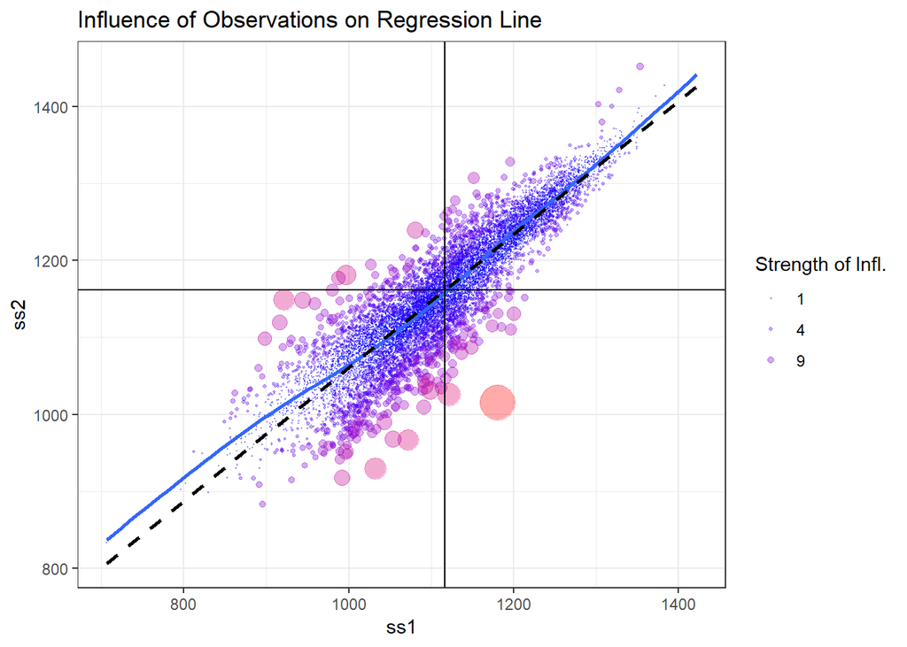

```r
# Define outlier status across these variables
sch_score_m1$outlier <- sch_score_m1$.hat + sch_score_m1$.cooksd + sch_score_m1$.std.resid

ggplot(sch_score_m1) + aes(x = ss1, y = ss2, color = outlier^2,
                        size = outlier^2) +
  geom_point(alpha = I(0.33)) +
  scale_colour_gradient(low = "blue", high="red", breaks = c(0, 1, 4, 9))+
  scale_radius(range = c(0,9), breaks = c(0, 1, 4, 9)) +
  guides(color = guide_legend(), size = guide_legend()) +
  labs(color = "Strength of Infl.", size = "Strength of Infl.",
       title = "Influence of Observations on Regression Line") +
  geom_smooth(se=FALSE, show.legend = FALSE) +
  geom_smooth(method= "lm", se=FALSE, show.legend = FALSE,
              color = I("black"), linetype = 2) +
  geom_hline(yintercept = mean(sch_score_m1$ss2)) +
  geom_vline(xintercept = mean(sch_score_m1$ss1)) + theme_bw()
```